# R Notebook

```r
library(ggfortify)
```

# Manual models

|  | education | income | women | prestige | census | type |
| --- | --- | --- | --- | --- | --- | --- |
| athletes | 11.44 | 8206 | 8.13 | 54.1 | 3373 | NA |
| newsboys | 9.62 | 918 | 7.00 | 14.8 | 5143 | NA |
| babysitters | 9.46 | 611 | 96.53 | 25.9 | 6147 | NA |
| farmers | 6.84 | 3643 | 3.60 | 44.1 | 7112 | NA |

## Feature engineering: logged some positively skewed numerics

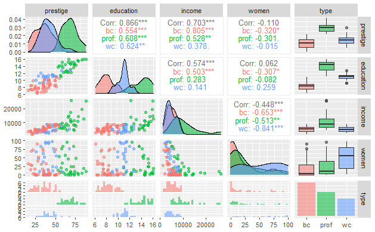

```r
prestige_trim %>%
  select(-c(ln_women, ln_income)) %>%
  select(prestige, everything()) %>%
  ggpairs(aes(colour = type, alpha = 0.5))
```

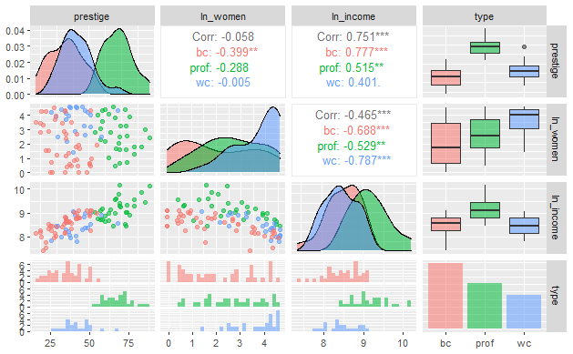

```r
prestige_trim %>%
  select(prestige,ln_women, ln_income, type) %>%
  #select(prestige, everything()) %>%
  ggpairs(aes(colour = type, alpha = 0.5))
```

|  | education | income | women | prestige | type | ln_women | ln_income |
| --- | --- | --- | --- | --- | --- | --- | --- |
| general.managers | 12.26 | 25879 | 4.02 | 69.1 | prof | 1.6134299 | 10.161187 |
| physicians | 15.96 | 25308 | 10.56 | 87.2 | prof | 2.4475509 | 10.138876 |
| lawyers | 15.77 | 19263 | 5.13 | 82.3 | prof | 1.8131947 | 9.865941 |
| osteopaths.chiropractors | 14.71 | 17498 | 6.91 | 68.4 | prof | 2.0681278 | 9.769842 |
| veterinarians | 15.94 | 14558 | 4.32 | 66.7 | prof | 1.6714733 | 9.585896 |
| architects | 15.44 | 14163 | 2.69 | 78.1 | prof | 1.3056265 | 9.558388 |
| pilots | 12.27 | 14032 | 0.58 | 66.1 | prof | 0.4574248 | 9.549096 |
| university.teachers | 15.97 | 12480 | 19.59 | 84.6 | prof | 3.0248055 | 9.431883 |
| gov.administrators | 13.11 | 12351 | 11.16 | 68.8 | prof | 2.4981519 | 9.421492 |
| civil.engineers | 14.52 | 11377 | 1.03 | 73.1 | prof | 0.7080358 | 9.339349 |

```r
mod1a <- lm(prestige ~ education,
            data = prestige_trim)

summary(mod1a)
```

```
Call:
lm(formula = prestige ~ education, data = prestige_trim)

Residuals:
    Min      1Q  Median      3Q     Max
-21.605  -6.151   0.366   6.565  17.540

Coefficients:
            Estimate Std. Error t value Pr(>|t|)
(Intercept) -10.8409     3.5285  -3.072  0.00276 **
education     5.3884     0.3168  17.006  < 2e-16 ***
---
Signif. codes:  0 ‘***’ 0.001 ‘**’ 0.01 ‘*’ 0.05 ‘.’ 0.1 ‘ ’ 1

Residual standard error: 8.578 on 96 degrees of freedom
Multiple R-squared:  0.7508,    Adjusted R-squared:  0.7482
F-statistic: 289.2 on 1 and 96 DF,  p-value: < 2.2e-16
```

[figure not shown]

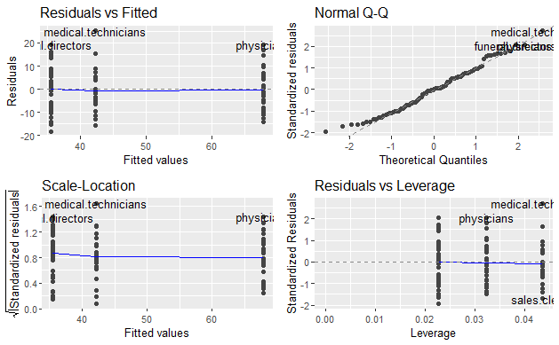

```r
mod1b <- lm(prestige ~ type, data = prestige_trim)

autoplot(mod1b)
```

```r
summary(mod1b)
```

```
Call:
lm(formula = prestige ~ type, data = prestige_trim)

Residuals:
     Min       1Q   Median       3Q      Max
-18.2273  -7.1773  -0.0854   6.1174  25.2565

Coefficients:
            Estimate Std. Error t value Pr(>|t|)
(Intercept)   35.527      1.432  24.810  < 2e-16 ***
typeprof      32.321      2.227  14.511  < 2e-16 ***
typewc         6.716      2.444   2.748  0.00718 **
---
Signif. codes:  0 ‘***’ 0.001 ‘**’ 0.01 ‘*’ 0.05 ‘.’ 0.1 ‘ ’ 1

Residual standard error: 9.499 on 95 degrees of freedom
Multiple R-squared:  0.6976,    Adjusted R-squared:  0.6913
F-statistic: 109.6 on 2 and 95 DF,  p-value: < 2.2e-16
```

type bc has an average prestige value of 35.52

For professional type jobs, we can expect to see, on average, an increase of 32.32 in prestige score compared to blue collar type jobs For white coller type jobs, we can expect to see, on average, an increase of 6.7 in prestige score compared to blue collar type jobs The model explains 70% of the variation in prestige score

Now we want to see which variables describe the “residue”, the unexplained model error

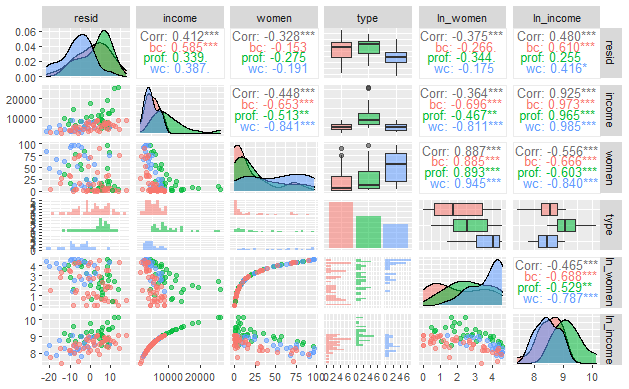

```r
prestige_resid <- prestige_trim %>%
  add_residuals(mod1a) %>%
  select(-c(prestige, education))

prestige_resid %>%
  select(resid, everything()) %>%
  ggpairs(aes(colour = type, alpha = 0.5))
```

## add a second predictor: next best

i.e. the one that explains the most residual error

```r
mod2a <- lm(prestige ~ education + ln_income,
            data = prestige_trim)

summary(mod2a)
```

```
Call:
lm(formula = prestige ~ education + ln_income, data = prestige_trim)

Residuals:
     Min       1Q   Median       3Q      Max
-16.6775  -4.0506  -0.2538   4.0648  16.7992

Coefficients:
             Estimate Std. Error t value Pr(>|t|)
(Intercept) -101.1882    12.8490  -7.875 5.51e-12 ***
education      4.0375     0.3173  12.726  < 2e-16 ***
ln_income     12.0564     1.6719   7.211 1.33e-10 ***
---
Signif. codes:  0 ‘***’ 0.001 ‘**’ 0.01 ‘*’ 0.05 ‘.’ 0.1 ‘ ’ 1

Residual standard error: 6.932 on 95 degrees of freedom
Multiple R-squared:  0.8389,    Adjusted R-squared:  0.8356
F-statistic: 247.4 on 2 and 95 DF,  p-value: < 2.2e-16
```

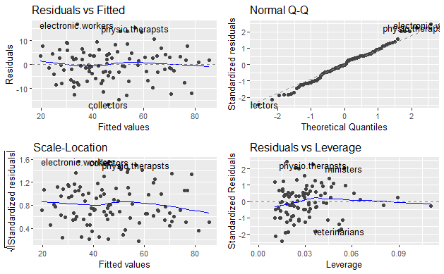

```r
autoplot(mod2a)
```

```r
mod2b <- lm(prestige ~ education + income,
            data = prestige_trim)

summary(mod2b)
```

```
Call:
lm(formula = prestige ~ education + income, data = prestige_trim)

Residuals:
     Min       1Q   Median       3Q      Max
-16.9367  -4.8881   0.0116   4.9690  15.9280

Coefficients:
              Estimate Std. Error t value Pr(>|t|)
(Intercept) -7.6210352  3.1162309  -2.446   0.0163 *
education    4.2921076  0.3360645  12.772  < 2e-16 ***
income       0.0012415  0.0002185   5.682 1.45e-07 ***
---
Signif. codes:  0 ‘***’ 0.001 ‘**’ 0.01 ‘*’ 0.05 ‘.’ 0.1 ‘ ’ 1

Residual standard error: 7.45 on 95 degrees of freedom
Multiple R-squared:  0.814, Adjusted R-squared:  0.8101
F-statistic: 207.9 on 2 and 95 DF,  p-value: < 2.2e-16
```

```r
mod2c <- lm(prestige ~ education + type,
            data = prestige_trim)

summary(mod2c)
```

```
Call:
lm(formula = prestige ~ education + type, data = prestige_trim)

Residuals:
    Min      1Q  Median      3Q     Max
-19.410  -5.508   1.360   5.694  17.171

Coefficients:
            Estimate Std. Error t value Pr(>|t|)
(Intercept)  -2.6982     5.7361  -0.470   0.6392
education     4.5728     0.6716   6.809 9.16e-10 ***
typeprof      6.1424     4.2590   1.442   0.1526
typewc       -5.4585     2.6907  -2.029   0.0453 *
---
Signif. codes:  0 ‘***’ 0.001 ‘**’ 0.01 ‘*’ 0.05 ‘.’ 0.1 ‘ ’ 1

Residual standard error: 7.814 on 94 degrees of freedom
Multiple R-squared:  0.7975,    Adjusted R-squared:  0.791
F-statistic: 123.4 on 3 and 94 DF,  p-value: < 2.2e-16
```

mod2a gave the biggest uplift in r2 and residuals look great - add it in to the model

## check of significance of categorical: ANOVA test

```r
anova(mod1a, mod2c)
```

```
Analysis of Variance Table

Model 1: prestige ~ education
Model 2: prestige ~ education + type
  Res.Df    RSS Df Sum of Sq      F    Pr(>F)
1     96 7064.4
2     94 5740.0  2    1324.4 10.844 5.787e-05 ***
---
Signif. codes:  0 ‘***’ 0.001 ‘**’ 0.01 ‘*’ 0.05 ‘.’ 0.1 ‘ ’ 1
```

it is statistically significant (i.e. the 3 levels have different means), so we can include type in the model with education

## third predictor!

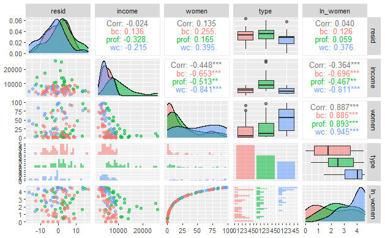

```r
prestige_resid <- prestige_trim %>%
  add_residuals(mod2a) %>%
  select(-c(prestige, education, ln_income))

prestige_resid %>%
  select(resid, everything()) %>%
  ggpairs(aes(colour = type, alpha = 0.5))
```

```r
mod3a <- lm(prestige ~ education + ln_income + women,
            data = prestige_trim)

summary(mod3a)
```

```
Call:
lm(formula = prestige ~ education + ln_income + women, data = prestige_trim)

Residuals:
     Min       1Q   Median       3Q      Max
-16.8202  -4.7019   0.0696   4.2245  17.6833

Coefficients:
              Estimate Std. Error t value Pr(>|t|)
(Intercept) -129.16790   18.95716  -6.814 8.97e-10 ***
education      3.59404    0.38431   9.352 4.39e-15 ***
ln_income     15.60547    2.43246   6.416 5.62e-09 ***
women          0.06481    0.03270   1.982   0.0504 .
---
Signif. codes:  0 ‘***’ 0.001 ‘**’ 0.01 ‘*’ 0.05 ‘.’ 0.1 ‘ ’ 1

Residual standard error: 6.828 on 94 degrees of freedom
Multiple R-squared:  0.8454,    Adjusted R-squared:  0.8405
F-statistic: 171.4 on 3 and 94 DF,  p-value: < 2.2e-16
```

```r
mod3b <- lm(prestige ~ education + ln_income + type,
            data = prestige_trim)

summary(mod3b)
```

```
Call:
lm(formula = prestige ~ education + ln_income + type, data = prestige_trim)

Residuals:
    Min      1Q  Median      3Q     Max
-13.511  -3.746   1.011   4.356  18.438

Coefficients:
            Estimate Std. Error t value Pr(>|t|)
(Intercept) -81.2019    13.7431  -5.909 5.63e-08 ***
education     3.2845     0.6081   5.401 5.06e-07 ***
ln_income    10.4875     1.7167   6.109 2.31e-08 ***
typeprof      6.7509     3.6185   1.866   0.0652 .
typewc       -1.4394     2.3780  -0.605   0.5465
---
Signif. codes:  0 ‘***’ 0.001 ‘**’ 0.01 ‘*’ 0.05 ‘.’ 0.1 ‘ ’ 1

Residual standard error: 6.637 on 93 degrees of freedom
Multiple R-squared:  0.8555,    Adjusted R-squared:  0.8493
F-statistic: 137.6 on 4 and 93 DF,  p-value: < 2.2e-16
```

[figure not shown]

```r
anova(mod2a, mod3b)
```

```
Analysis of Variance Table

Model 1: prestige ~ education + ln_income
Model 2: prestige ~ education + ln_income + type
  Res.Df    RSS Df Sum of Sq      F   Pr(>F)
1     95 4565.4
2     93 4096.3  2    469.07 5.3247 0.006465 **
---
Signif. codes:  0 ‘***’ 0.001 ‘**’ 0.01 ‘*’ 0.05 ‘.’ 0.1 ‘ ’ 1
```

Diagnostic plots are fine, anova test is significant, let’s add type to the model.

## adding an interaction (between existing main effects)

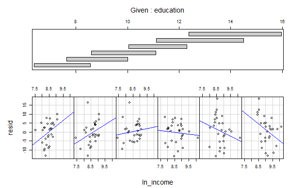

```r
coplot(resid ~ ln_income | education,
       panel = function(x, y, ...){
         points(x, y)
         abline(lm(y ~ x), col = "blue")
       },
       data = prestige_resid,
       rows = 1)
```

The effects of income are different for different levels of education, so it could be worth adding them into the model

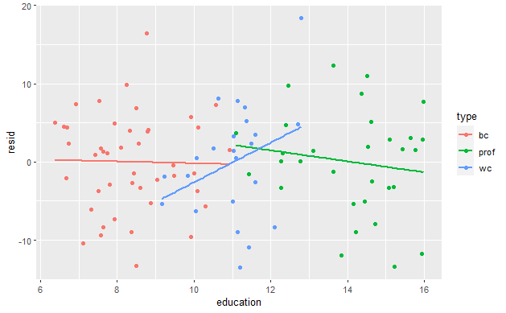

The effects of education are different for different types of workers

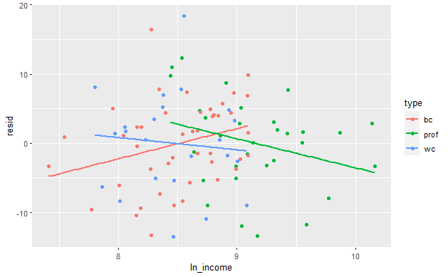

```r
prestige_resid %>%
  ggplot(aes(x = ln_income,
             y = resid,
             colour = type))+
  geom_point()+
  geom_smooth(method = "lm", se = FALSE)
```

```r
mod4a <- lm(prestige ~ education + ln_income + type +
              education:ln_income,
            data = prestige_trim)

summary(mod4a)
```

```
Call:
lm(formula = prestige ~ education + ln_income + type + education:ln_income,
    data = prestige_trim)

Residuals:
     Min       1Q   Median       3Q      Max
-13.6129  -4.1461   0.7695   4.1546  17.9453

Coefficients:
                     Estimate Std. Error t value Pr(>|t|)
(Intercept)         -166.7630    51.0506  -3.267 0.001530 **
education             11.1444     4.5601   2.444 0.016438 *
ln_income             20.2741     5.8790   3.449 0.000852 ***
typeprof               6.8626     3.5803   1.917 0.058374 .
typewc                -2.3516     2.4103  -0.976 0.331796
education:ln_income   -0.8892     0.5114  -1.739 0.085414 .
---
Signif. codes:  0 ‘***’ 0.001 ‘**’ 0.01 ‘*’ 0.05 ‘.’ 0.1 ‘ ’ 1

Residual standard error: 6.566 on 92 degrees of freedom
Multiple R-squared:  0.8601,    Adjusted R-squared:  0.8525
F-statistic: 113.1 on 5 and 92 DF,  p-value: < 2.2e-16
```

```r
mod4b <- lm(prestige ~ education + ln_income + type +
              education:type,
            data = prestige_trim)

summary(mod4b)
```

```
Call:
lm(formula = prestige ~ education + ln_income + type + education:type,
    data = prestige_trim)

Residuals:
    Min      1Q  Median      3Q     Max
-13.962  -3.797   1.041   4.092  16.503

Coefficients:
                   Estimate Std. Error t value Pr(>|t|)
(Intercept)        -81.6672    14.3681  -5.684 1.57e-07 ***
education            3.1407     0.9004   3.488 0.000751 ***
ln_income           10.6833     1.7108   6.245 1.33e-08 ***
typeprof            15.6176    14.2168   1.099 0.274871
typewc             -30.4466    18.3465  -1.660 0.100451
education:typeprof  -0.5801     1.2211  -0.475 0.635887
education:typewc     2.6675     1.7551   1.520 0.132018
---
Signif. codes:  0 ‘***’ 0.001 ‘**’ 0.01 ‘*’ 0.05 ‘.’ 0.1 ‘ ’ 1

Residual standard error: 6.585 on 91 degrees of freedom
Multiple R-squared:  0.8608,    Adjusted R-squared:  0.8516
F-statistic: 93.79 on 6 and 91 DF,  p-value: < 2.2e-16
```

```r
mod4c <- lm(prestige ~ education + ln_income + type +
              ln_income:type,
            data = prestige_trim)

summary(mod4c)
```

```
Call:
lm(formula = prestige ~ education + ln_income + type + ln_income:type,
    data = prestige_trim)

Residuals:
    Min      1Q  Median      3Q     Max
-13.484  -4.453   1.122   4.123  18.737

Coefficients:
                    Estimate Std. Error t value Pr(>|t|)
(Intercept)        -118.4325    20.3728  -5.813 8.97e-08 ***
education             3.2107     0.5993   5.357 6.31e-07 ***
ln_income            14.9336     2.4928   5.991 4.12e-08 ***
typeprof             82.7757    31.5059   2.627   0.0101 *
typewc               51.3717    36.8521   1.394   0.1667
ln_income:typeprof   -8.5690     3.5251  -2.431   0.0170 *
ln_income:typewc     -6.1925     4.3172  -1.434   0.1549
---
Signif. codes:  0 ‘***’ 0.001 ‘**’ 0.01 ‘*’ 0.05 ‘.’ 0.1 ‘ ’ 1

Residual standard error: 6.491 on 91 degrees of freedom
Multiple R-squared:  0.8647,    Adjusted R-squared:  0.8558
F-statistic: 96.96 on 6 and 91 DF,  p-value: < 2.2e-16
```

[figure not shown]

```r
anova(mod3b, mod4c)
```

```
Analysis of Variance Table

Model 1: prestige ~ education + ln_income + type
Model 2: prestige ~ education + ln_income + type + ln_income:type
  Res.Df    RSS Df Sum of Sq      F  Pr(>F)
1     93 4096.3
2     91 3834.2  2    262.13 3.1107 0.04934 *
---
Signif. codes:  0 ‘***’ 0.001 ‘**’ 0.01 ‘*’ 0.05 ‘.’ 0.1 ‘ ’ 1
```

```r
#this breaks down the relative importance of each of the predictors - it breaks down the r^2 value
library(relaimpo)

calc.relimp(mod4c, type = "lmg", rela = TRUE)
```

```
Response variable: prestige
Total response variance: 292.2358
Analysis based on 98 observations

6 Regressors:
Some regressors combined in groups:
        Group  type : typeprof typewc
        Group  ln_income:type : ln_income:typeprof ln_income:typewc

 Relative importance of 4 (groups of) regressors assessed:
 type ln_income:type education ln_income

Proportion of variance explained by model: 86.47%
Metrics are normalized to sum to 100% (rela=TRUE).

Relative importance metrics:

                      lmg
type           0.38512449
ln_income:type 0.01146495
education      0.29662098
ln_income      0.30678958

Average coefficients for different model sizes:

                      1group   2groups   3groups   4groups
education           5.388408  4.305159  3.284486  3.210707
ln_income          24.619472 12.879804 14.634783 14.933637
typeprof           32.321114 14.810837 54.690682 82.775730
typewc              6.716206  1.013706 41.131305 51.371716
ln_income:typeprof       NaN       NaN -9.001091 -8.568986
ln_income:typewc         NaN       NaN -8.979324 -6.192503
```